# **Should Olist remove underperforming sellers from its marketplace?** 🕵🏻

In doing so, we want to **improve**:

- net profit
- average review score (aka customer satisfaction)

## Answer: Yes.

Remove the bottom ~300 sellers that are contributing negatively to both:

- Olist's net profit
- Olist's reputation (by lowering overall average seller review score)

## How did we come to this conclusion?

'What-if' analysis

What if Olist had never accepted certain underperforming sellers in the first place?

### Definitions: what criteria do we use to define an *underperforming* seller?

We will **simplify** seller performance to account for as many parameters as possible by quantifying:

- **revenue** brought to Olist
  - 10% of sales made by seller
  - 80 BRL per month platform fee to Olist
- **costs** incurred to Olist
  1. review-based
     - 100 BRL per 1-star review
     - 50 BRL per 2-star review
     - 40 BRL per 3-star review
  2. order-based
     - IT cost proportional to volume of orders brought in by the seller

An underperforming seller would be one that brings more costs than revenue to Olist (negative profit).

### Procedure

*Maximizing net profit*

1. calculate each seller's net profit contribution to Olist
2. simulate new net profit by removing sellers one by one, starting with lowest
3. find the optimal number of sellers removed where **Olist's net profit is maximized**

*Adding in customer satisfaction considerations*

4. observe effect on overall average seller review as sellers are removed
5. is there an optimum point for both net profit and overall average seller review?

### The current state (profit to-date)

| Summary | Value |
| --- | --- |
| Number of orders | 95,872 |
| Revenue | 2,782,658 |
| Net Profit | 883,388 |
| Net Profit Margin | 31.75% |

#### What happens to Olist net profit as we start to remove sellers, starting with the most underperforming (negative) and slowly moving upwards?

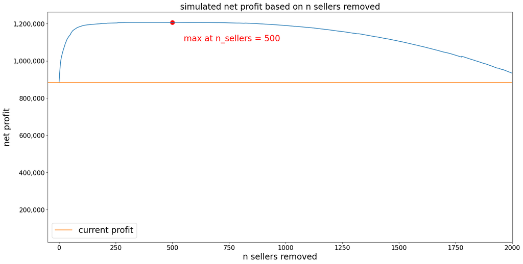

#### What is the effect on net profit margin?

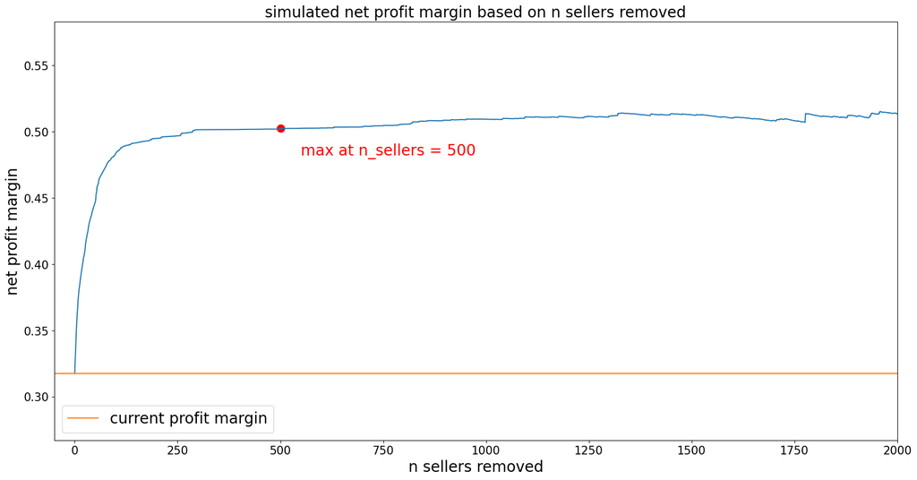

#### How does removing these sellers affect our overall average seller review?

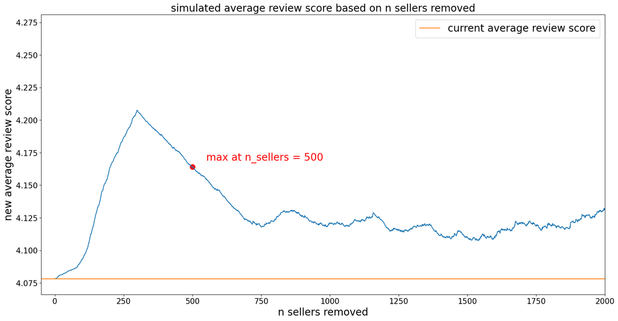

#### The maximum for simulated average review scores actually occurs earlier at n = 298.

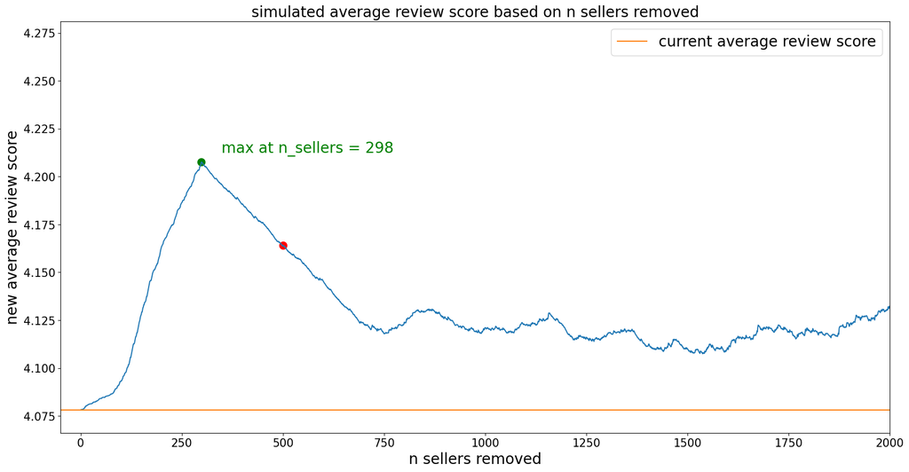

Since we are also thinking about **maximizing average review score** in addition to **maximizing profit**, what does removing n = 298 sellers look like on our previous profit and profit margin graphs?

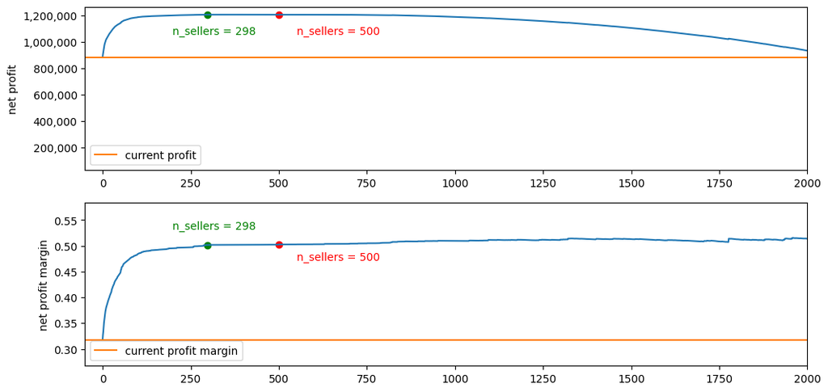

Removing 298 sellers vs. 500 sellers yields **nearly no difference** in simulated profit and profit margin.

Maybe we can just remove n = 298 sellers as our optimum.

|  | n = 500 | n = 298 | change |
| --- | --- | --- | --- |
| profit | 1,207,138.0000 | 1,206,912.0000 | -0.02% |
| profit margin | 0.5025 | 0.5015 | -0.20% |
| avg review score | 4.1600 | 4.2100 | 1.20% |

By choosing n = 298 over n = 500, we observe:

- **less than 1% loss** in profit and profit margin
- **1.2% gain** in average review score